# Homework 1

Xiang Yang Ng

April 12, 2018

Changing the working directory

```r
setwd("/Users/Lenovo/Desktop/Econ 144/Homework/Hw 1")
```

## Problem 1

Clear all variables and prior sessions

```r
rm(list=ls(all=TRUE))

library(DAAG)
library(lattice)
library(foreign)
library(MASS)
library(car)
require(stats)
require(stats4)
library(KernSmooth)
library(fastICA)
library(cluster)
library(leaps)
library(mgcv)
```

```r
library(rpart)
library(pan)
library(mgcv)
library(e1071)
library(corrplot)
```

Imported the dataset from DAAG’

```r
data = data.frame(nsw74psid1)
attach(data)
```

1. Plot a histogram of each variable and discuss its properties.

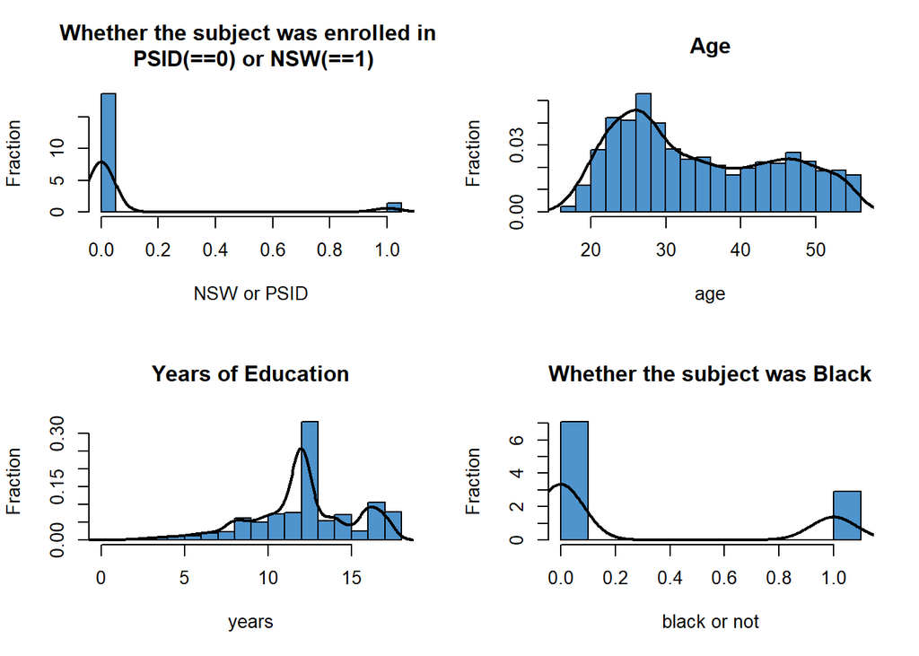

```r
windows()
par(mfrow=c(2,2))
truehist(trt,col='steelblue3',main="Whether the subject was enrolled in \n PSID(==0) or NSW(==1)",xlab="NSW or PSID", ylab="Fraction")
lines(density(trt),lwd=2)

truehist(age,col='steelblue3',main="Age",xlab="age", ylab="Fraction")
lines(density(age),lwd=2)

truehist(educ,col='steelblue3',main="Years of Education",xlab="years", ylab="Fraction")
lines(density(educ),lwd=2)

truehist(black,col='steelblue3',main="Whether the subject was Black",xlab="black or not", ylab="Fraction")
lines(density(black),lwd=2)
```

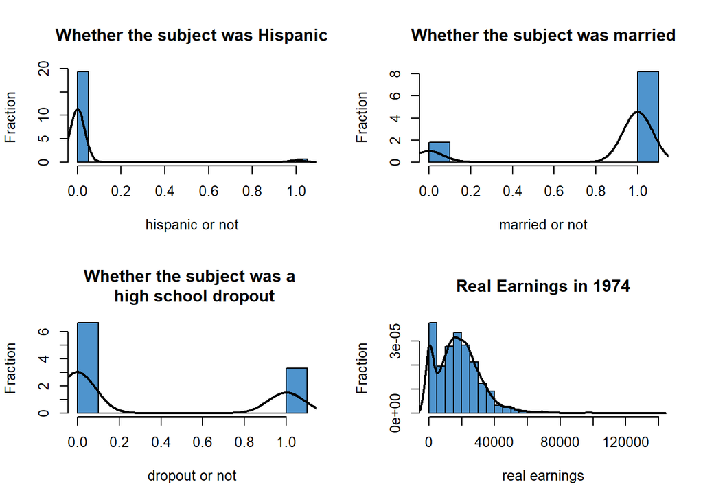

```r
windows()
par(mfrow=c(2,2))
truehist(hisp,col='steelblue3',main="Whether the subject was Hispanic",xlab="hispanic or not", ylab="Fraction")
lines(density(hisp),lwd=2)

truehist(marr,col='steelblue3',main="Whether the subject was married",xlab="married or not", ylab="Fraction")
lines(density(marr),lwd=2)

truehist(nodeg,col='steelblue3',main="Whether the subject was a \n high school dropout",xlab="dropout or not", ylab="Fraction")
lines(density(nodeg),lwd=2)

truehist(re74,col='steelblue3',main="Real Earnings in 1974",xlab="real earnings", ylab="Fraction")
lines(density(re74),lwd=2)
```

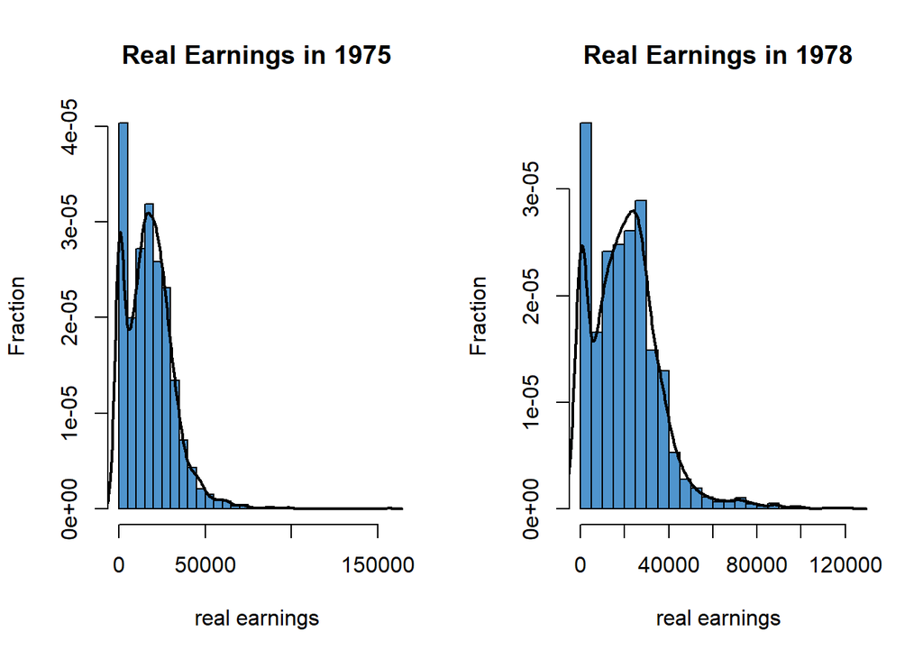

```r
windows()
par(mfrow=c(1,2))
truehist(re75,col='steelblue3',main="Real Earnings in 1975",xlab="real earnings", ylab="Fraction")
lines(density(re75),lwd=2)

truehist(re78,col='steelblue3',main="Real Earnings in 1978",xlab="real earnings", ylab="Fraction")
lines(density(re78),lwd=2)
```

2. Estimate your full regression model and show your results (e.g., the output from the `summary’ command in R). Discuss these results.

```r
y = lm(re78~trt+age+educ+black)
summary(y)
```

```
##
## Call:
## lm(formula = re78 ~ trt + age + educ + black)
##
## Residuals:
##    Min     1Q Median     3Q    Max
## -34507  -7311   -148   7071 106726
##
## Coefficients:
##             Estimate Std. Error t value Pr(>|t|)
## (Intercept) -5761.73    1771.01  -3.253  0.00115 **
## trt         -8398.25    1156.55  -7.261 5.00e-13 ***
## age           195.55      27.29   7.165 1.00e-12 ***
## educ         1759.08      97.41  18.058  < 2e-16 ***
## black       -3247.63     668.11  -4.861 1.24e-06 ***
## ---
## Signif. codes:  0 '***' 0.001 '**' 0.01 '*' 0.05 '.' 0.1 ' ' 1
##
## Residual standard error: 13990 on 2670 degrees of freedom
## Multiple R-squared:  0.2006, Adjusted R-squared:  0.1994
## F-statistic: 167.5 on 4 and 2670 DF,  p-value: < 2.2e-16
```

I did not use the all the predictors/variables since I thought that some of them are statistically insignificant. Since the p-values are so small, the estimated coefficients that we obtained by running the regression is statistically significant. However since the R^2 is so low, the model does not fit the data.

3. Compute the Mallows CP statistic for all the plausible models and choose only one model. Discuss why you chose this model. For the next questions, only use your selected model from this part.

```r
windows()
ss=leaps::regsubsets(re78~trt+age+educ+black,method=c("exhaustive"),nbest=4,data=data)
subsets(ss,statistic="cp",legend=F,main="Mallows CP",col="steelblue4")
```

```
##       Abbreviation
## trt              t
## age              a
## educ             e
## black            b
```

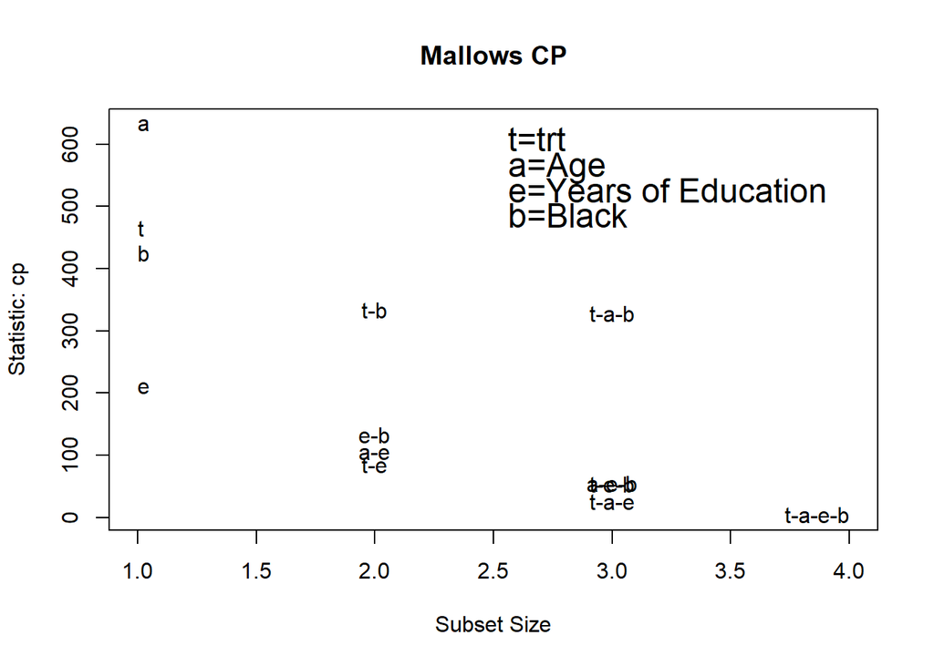

```r
legend(2.3,650,bty="n",legend=c('t=trt','a=Age','e=Years of Education', 'b=Black'),col="steelblue4",cex=1.5)
```

From the Mallows Cp, we can see that the choosing all 4 variables would give the lowest Cp. However, the Cp is sufficiently low enough when we just take trt, age and educ variables. So I’ll use these variables.

```r
y1 = lm(re78~trt+age+educ)
```

4. Plot the residuals vs. the fitted values.

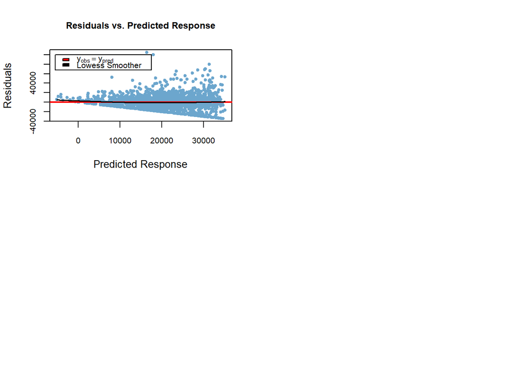

```r
windows()
par(mfcol=c(2,2))
plot(y1$fit,y1$res,col="skyblue3",pch=20,xlab="Predicted Response",ylab="Residuals",main="Residuals vs. Predicted Response",cex.axis=0.8,cex.main=0.9)
abline(h=0,lwd=2,col="red")
lines(lowess(y1$fit,y1$res),lwd=1.5)
abline(v=6e5,col="red",lty=2,lwd=1.5)
legend(-5500,100000,c(expression(y[obs]==y[pred]), "Lowess Smoother"), fill =c("red", "black"),cex=0.8)
```

(e)Plot and discuss the VIF plot.

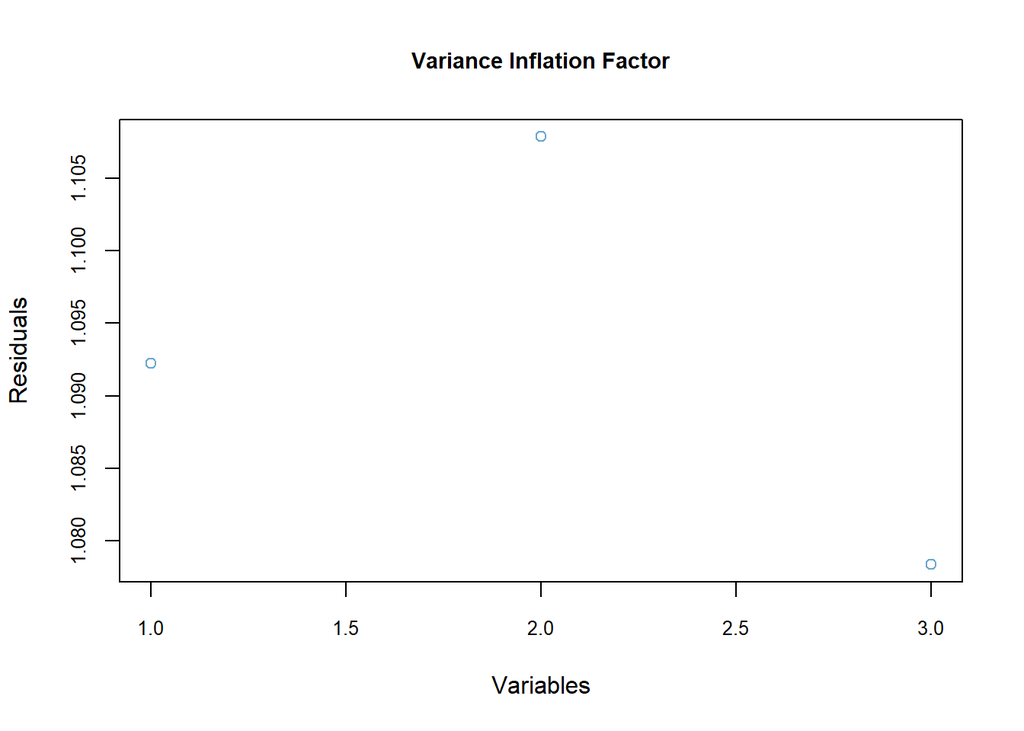

```r
plot(vif(y1),col="skyblue3",xlab="Variables",ylab="Residuals",main="Variance Inflation Factor",cex.axis=0.8,cex.main=0.9)
```

The VIF for variables trt, age and educ are 1.092, 1.108 and 1.078, which are very small. Therefore, they are not collinear.

6. Plot and discuss the correlation graph (use the corrplot library).

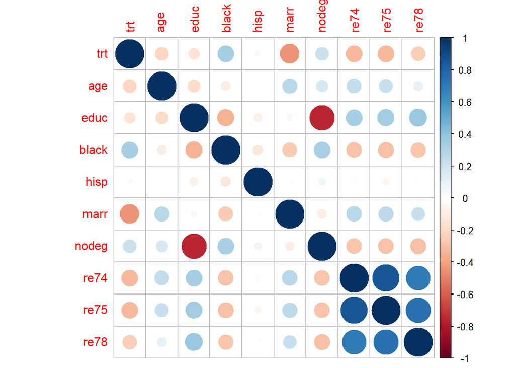

```r
M <- cor(data)
corrplot(M, method = "circle")
```

7. Plot the Cook’s Distance values. Are there any outliers? If so, discuss what you would do with them.

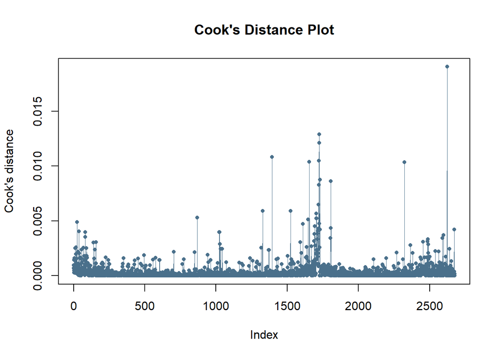

```r
y1_cook=cooks.distance(y1)
plot(y1_cook,ylab="Cook's distance",type='o',main="Cook's Distance Plot",col="skyblue4", pch=20,lwd=.25)
text(7,0.28,"wt=5345lbs \n 8-Cyl \n  hp=230 \n mpg=14.7")
text(14,0.33, expression(""%->%""))
```

From the plot, we could see that there are outliers. One way to deal with it is to consider modifying the model, such as to a log-linear one. Since we could see that there is only one outlier that stands out too much, another way is to just remove that point.

8. Plot a histogram of the residuals and discuss the results.

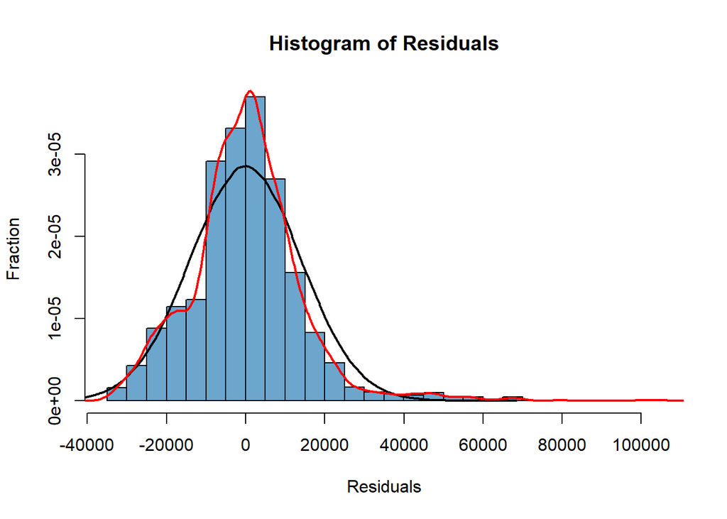

```r
truehist(y1$res,col="skyblue3",xlab="Residuals",ylab="Fraction",main="Histogram of Residuals")
xr=rnorm(800000,mean(y1$res),sd(y1$res))
lines(density(xr),col="black",lwd=2)
lines(density(y1$res),col="red",lwd=2)
legend(0.3,0.2,c("Density","Normal Distr."),fill=c("red","black"),bty='n')
```

1. Plot the QQ Normal Plot and discuss the results.

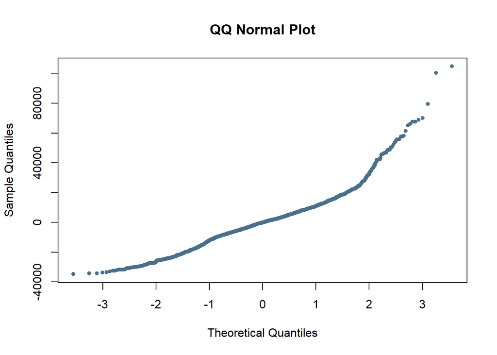

```r
qqnorm(y1$res,col="skyblue4", pch=20,lwd=1,main="QQ Normal Plot")
```

Since the shape of the line is slope slightly upwards, maybe the linear model does not fit the data well. However we could that there are some points that jump at the right tail, which implies that we have outliers.

10. Plot the observed vs. predicted values, overlay a Lowess smoother, and discuss the results.

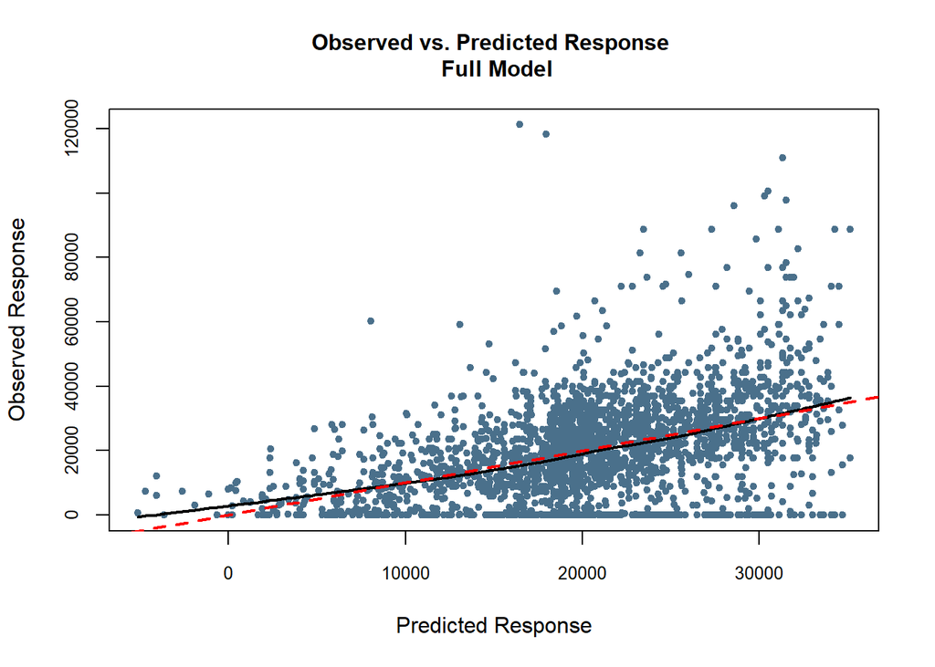

```r
windows()
plot(y1$fit,re78,pch=20,col="skyblue4",cex=1,xlab="Predicted Response",ylab="Observed Response",main="Observed vs. Predicted Response \n Full Model",cex.axis=0.8,cex.main=1.0)
lines(lowess(y1$fit,re78),lwd=2)
abline(0,1,col="red",lwd=2,lty=2)
```

The way the plots scatter all over indicates that there is very little correspondence between the observed values and the predicted values. This means that the model for prediction is poor.

## Problem 2

clear all variables and prior sessions and get the data and attach it

```r
rm(list=ls(all=TRUE))
data = read.csv("2.2.csv", header = T)
attach(data)
```

Obtain the descriptive statistics: mean, median, variance, standard deviation, skewness, and kurtosis.

```r
print(paste("The mean of the GDP quarterly growth rates is ", mean(GRGDP)))
```

```
## [1] "The mean of the GDP quarterly growth rates is  0.795803870967742"
```

```r
print(paste("The median of the GDP quarterly growth rates is ", median(GRGDP)))
```

```
## [1] "The median of the GDP quarterly growth rates is  0.76789"
```

```r
print(paste("The variance of the GDP quarterly growth rates is ", var(GRGDP)))
```

```
## [1] "The variance of the GDP quarterly growth rates is  0.951862567096696"
```

```r
print(paste("The standard deviation of the GDP quarterly growth rates is ", (var(GRGDP)^(0.5))))
```

```
## [1] "The standard deviation of the GDP quarterly growth rates is  0.975634443373488"
```

```r
print(paste("The skewness of the GDP quarterly growth rates is ", skewness(GRGDP)))
```

```
## [1] "The skewness of the GDP quarterly growth rates is  -0.187714593795853"
```

```r
print(paste("The kurtosis of the GDP quarterly growth rates is ", kurtosis(GRGDP)))
```

```
## [1] "The kurtosis of the GDP quarterly growth rates is  1.38288523763476"
```

```r
print(paste("The mean of the S&P500 quarterly returns is ", mean(RETURN)))
```

```
## [1] "The mean of the S&P500 quarterly returns is  1.96210425806452"
```

```r
print(paste("The median of the S&P500 quarterly returns is ", median(RETURN)))
```

```
## [1] "The median of the S&P500 quarterly returns is  2.0227015"
```

```r
print(paste("The variance of the S&P500 quarterly returns is ", var(RETURN)))
```

```
## [1] "The variance of the S&P500 quarterly returns is  36.9271348635885"
```

```r
print(paste("The standard deviation of the S&P500 quarterly returns is ", (var(RETURN)^(0.5))))
```

```
## [1] "The standard deviation of the S&P500 quarterly returns is  6.07677010126173"
```

```r
print(paste("The skewness of the S&P500 quarterly returns is ", skewness(RETURN)))
```

```
## [1] "The skewness of the S&P500 quarterly returns is  -0.679887149724607"
```

```r
print(paste("The kurtosis of the S&P500 quarterly returns is ", kurtosis(RETURN)))
```

```
## [1] "The kurtosis of the S&P500 quarterly returns is  2.22845965467761"
```

Histograms

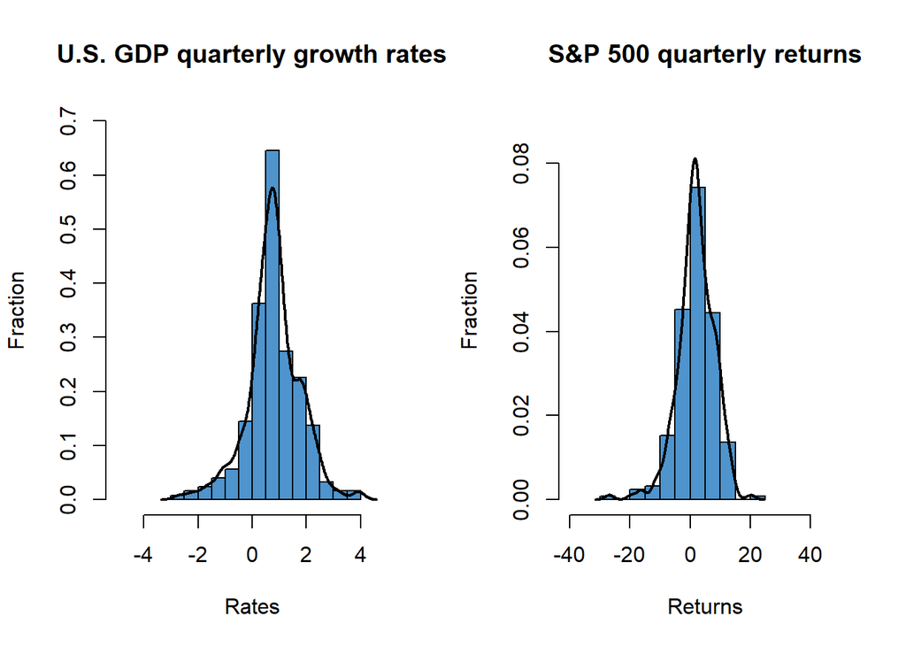

```r
windows()
par(mfrow=c(1,2))
truehist(GRGDP,col='steelblue3',main="U.S. GDP quarterly growth rates",xlab="Rates", ylab="Fraction",
         xlim=c(-5,5),ylim=c(0,0.7))
lines(density(GRGDP),lwd=2)

truehist(RETURN,col='steelblue3',main="S&P 500 quarterly returns",xlab="Returns", ylab="Fraction",
         xlim=c(-40,50),ylim=c(0,0.09))
lines(density(RETURN),lwd=2)
```

Correlation

```r
print ("The correlation matrix is: ")
```

```
## [1] "The correlation matrix is: "
```

```r
cor(cbind(GRGDP, RETURN))
```

```
##            GRGDP    RETURN
## GRGDP  1.0000000 0.2702427
## RETURN 0.2702427 1.0000000
```

# Problem 3

Clear all variables and prior sessions and obtain the data

```r
rm(list=ls(all=TRUE))
data = read.csv("3.1.csv", header = T)
attach(data)
```

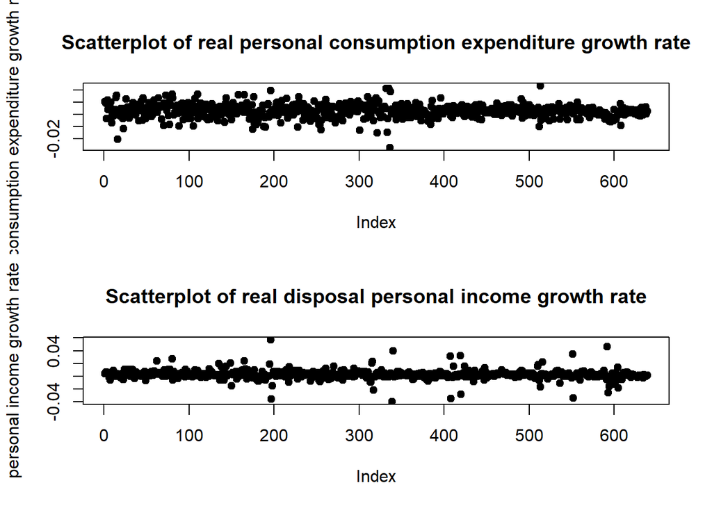

```r
rpce_pctchg = diff(log(rpce))
rdpi_pctchg = diff(log(rdpi))

windows()
par(mfrow = c(2,1))
plot(rpce_pctchg, main="Scatterplot of real personal consumption expenditure growth rate",
     ylab="consumption expenditure growth rate", pch=19)
plot(rdpi_pctchg, main="Scatterplot of real disposal personal income growth rate",
     ylab="personal income growth rate", pch=19)
```

From the plots, we can see that growth rate of the real personal consumption expenditure growth rate is less volatile than that of real disposal personal income, which can be explained by the permanent income model. Permanent income model that the current expenditure is not determined just by their current income but also by their future expected income. As such, it would mean that even if a person’s income varies, which some occasional outliers, his consumption might not vary since he could be saving the more for a rainy day.

```r
y = lm(rpce_pctchg~rdpi_pctchg)
summary(y)
```

```
##
## Call:
## lm(formula = rpce_pctchg ~ rdpi_pctchg)
##
## Residuals:
##        Min         1Q     Median         3Q        Max
## -0.0303967 -0.0029727  0.0001525  0.0030417  0.0244545
##
## Coefficients:
##              Estimate Std. Error t value Pr(>|t|)
## (Intercept) 0.0022542  0.0002242  10.055  < 2e-16 ***
## rdpi_pctchg 0.1745671  0.0292029   5.978 3.77e-09 ***
## ---
## Signif. codes:  0 '***' 0.001 '**' 0.01 '*' 0.05 '.' 0.1 ' ' 1
##
## Residual standard error: 0.005318 on 637 degrees of freedom
## Multiple R-squared:  0.05312,    Adjusted R-squared:  0.05163
## F-statistic: 35.73 on 1 and 637 DF,  p-value: 3.768e-09
```

both values for the intercept and the coefficient of income have very low p value, which means that they are statistically significant. The intercept is close to 0, which means that if the person’s income is 0, he would not consume. The income coefficient is positive, which means that the higher the income, the more the person will consume

```r
rdpi_pctchg_lag = c(NA,rdpi_pctchg[-length(rdpi_pctchg)])
y = lm(rpce_pctchg~rdpi_pctchg+rdpi_pctchg_lag)
summary(y)
```

```
##
## Call:
## lm(formula = rpce_pctchg ~ rdpi_pctchg + rdpi_pctchg_lag)
##
## Residuals:
##        Min         1Q     Median         3Q        Max
## -0.0300734 -0.0028702 -0.0000006  0.0029797  0.0255131
##
## Coefficients:
##                  Estimate Std. Error t value Pr(>|t|)
## (Intercept)     0.0019887  0.0002405   8.268 7.98e-16 ***
## rdpi_pctchg     0.1872692  0.0293883   6.372 3.58e-10 ***
## rdpi_pctchg_lag 0.0828596  0.0293877   2.820  0.00496 **
## ---
## Signif. codes:  0 '***' 0.001 '**' 0.01 '*' 0.05 '.' 0.1 ' ' 1
##
## Residual standard error: 0.005285 on 635 degrees of freedom
##   (1 observation deleted due to missingness)
## Multiple R-squared:  0.06479,    Adjusted R-squared:  0.06185
## F-statistic:    22 on 2 and 635 DF,  p-value: 5.8e-10
```

## Problem 4

clear all variables and prior sessions and obtain the data and create time series objects

```r
rm(list=ls(all=TRUE))
rgdp1 = read.csv("3.3a.csv", header = T)
attach(rgdp1)
rgdp_ts<-ts(rgdp,start=1948,freq=4)

jpusforex = read.csv("3.3b.csv", header = T)
attach(jpusforex)
jpusforex_ts<-ts(jpy_usd,start=1971,freq=252)

tcmr = read.csv("3.3c.csv", header = T)
attach(tcmr)
tcmr_ts<-ts(CMRate10Yr,start=1971,freq=252)

cer = read.csv("3.3d.csv", header = T)
attach(cer)
cer_ts<-ts(unemrate,start=1948, freq=12)
```

Create the scatterplots

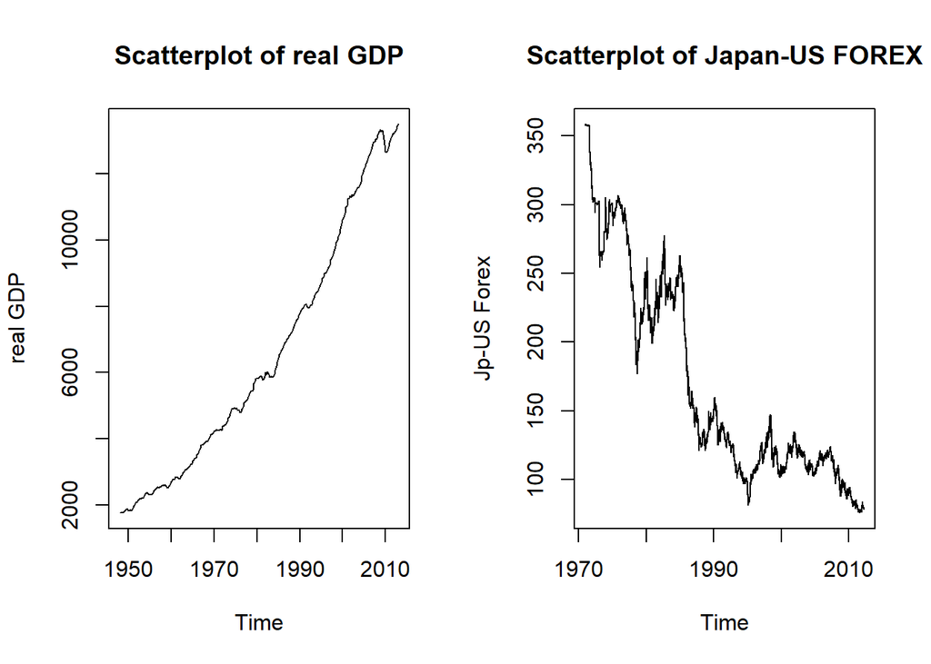

```r
windows()
par(mfrow = c(1,2))
plot(rgdp_ts, main="Scatterplot of real GDP",
     ylab="real GDP", pch=19)
plot(jpusforex_ts, main="Scatterplot of Japan-US FOREX",
     ylab="Jp-US Forex", pch=19)
```

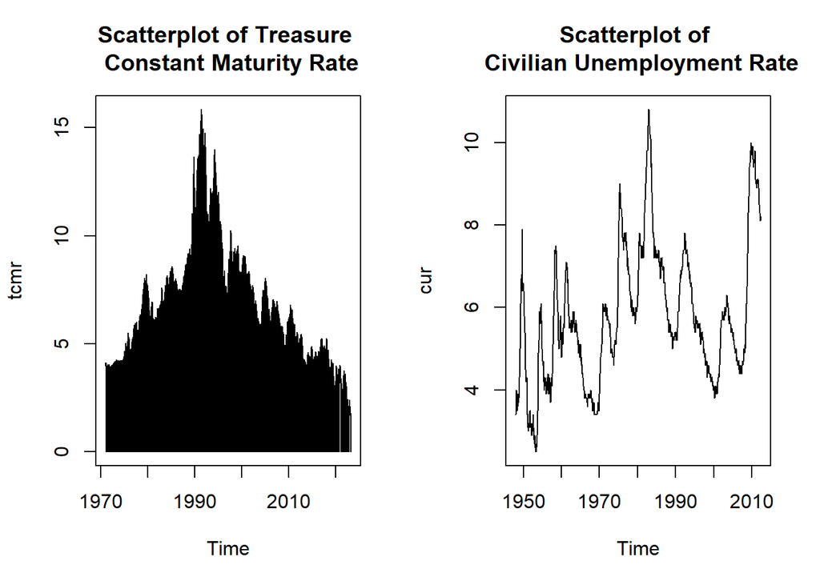

```r
windows()
par(mfrow = c(1,2))
plot(tcmr_ts, main="Scatterplot of Treasure \n Constant Maturity Rate",
     ylab="tcmr", pch=19)
plot(cer_ts, main="Scatterplot of \n Civilian Unemployment Rate",
     ylab="cur", pch=19)
```

All 4 scatterplots of time series, i.e those of real GDP, Japan-US FOREX and Treasury Constant Maturity Rate, Civilian Unemployment Rate show no equal mean for its stochastic processes over time. This means that there these time series are neither first nor second order weakly stationary.

## Problem 5

clear all variables and prior sessions and obtain the data

```r
rm(list=ls(all=TRUE))
hpir = read.csv("4.31.csv", header = T)
attach(hpir)
```

Obtain the house prices growth and the interest rate change

```r
hp_growth = diff(log(P))
ir_chg = diff(R..in...)
```

Obtain the ACF and PCF of house prices, interest rates, house prices growth and interest rate changes

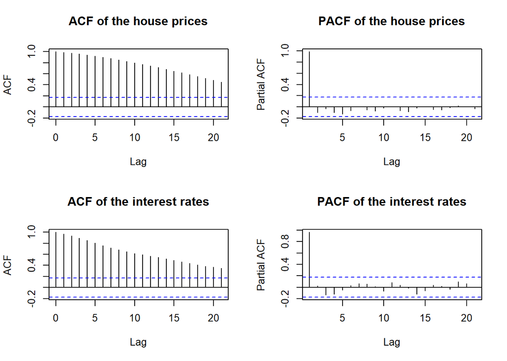

```r
windows()
par(mfrow=c(2,2))
acf(P,main="ACF of the house prices")
pacf(P,main="PACF of the house prices")

acf(R..in...,main="ACF of the interest rates")
pacf(R..in...,main="PACF of the interest rates")
```

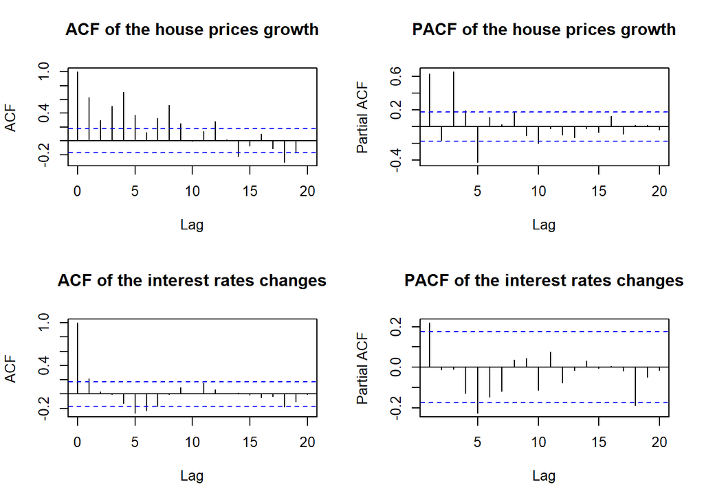

```r
windows()
par(mfrow=c(2,2))
acf(hp_growth,main="ACF of the house prices growth")
pacf(hp_growth,main="PACF of the house prices growth")

acf(ir_chg,main="ACF of the interest rates changes")
pacf(ir_chg,main="PACF of the interest rates changes")
```